# Ames Housing EDA

```r
install.packages("tidyverse")
install.packages("AmesHousing")
```

```r
library(ggplot2)
library("AmesHousing")
library(dplyr)
```

#AmesHousing 데이터의 변수 설명확인

```
##  [1] "Order"           "PID"             "MS SubClass"     "MS Zoning"
##  [5] "Lot Frontage"    "Lot Area"        "Street"          "Alley"
##  [9] "Lot Shape"       "Land Contour"    "Utilities"       "Lot Config"
## [13] "Land Slope"      "Neighborhood"    "Condition 1"     "Condition 2"
## [17] "Bldg Type"       "House Style"     "Overall Qual"    "Overall Cond"
## [21] "Year Built"      "Year Remod/Add"  "Roof Style"      "Roof Matl"
## [25] "Exterior 1st"    "Exterior 2nd"    "Mas Vnr Type"    "Mas Vnr Area"
## [29] "Exter Qual"      "Exter Cond"      "Foundation"      "Bsmt Qual"
## [33] "Bsmt Cond"       "Bsmt Exposure"   "BsmtFin Type 1"  "BsmtFin SF 1"
## [37] "BsmtFin Type 2"  "BsmtFin SF 2"    "Bsmt Unf SF"     "Total Bsmt SF"
## [41] "Heating"         "Heating QC"      "Central Air"     "Electrical"
## [45] "1st Flr SF"      "2nd Flr SF"      "Low Qual Fin SF" "Gr Liv Area"
## [49] "Bsmt Full Bath"  "Bsmt Half Bath"  "Full Bath"       "Half Bath"
## [53] "Bedroom AbvGr"   "Kitchen AbvGr"   "Kitchen Qual"    "TotRms AbvGrd"
## [57] "Functional"      "Fireplaces"      "Fireplace Qu"    "Garage Type"
## [61] "Garage Yr Blt"   "Garage Finish"   "Garage Cars"     "Garage Area"
## [65] "Garage Qual"     "Garage Cond"     "Paved Drive"     "Wood Deck SF"
## [69] "Open Porch SF"   "Enclosed Porch"  "3Ssn Porch"      "Screen Porch"
## [73] "Pool Area"       "Pool QC"         "Fence"           "Misc Feature"
## [77] "Misc Val"        "Mo Sold"         "Yr Sold"         "Sale Type"
## [81] "Sale Condition"  "SalePrice"
```

Factor 변수들과 covariate 변수들이 확인되므로 factor 변수안에 level별 SalePrice의 평균에 큰 차이를 보이면 설명변수 후보로 생각하고 covariate 변수와 SalePrice간에 corrlation이 보이면 설명변수 후보로 일단 간주하겠다. 또한 factor 변수들의 level별 데이터 수가 작을 경우와 level의 수가 너무 많을 경우 평균에 큰 차이를 보여도 설명변수에서 제외하겠다.

```r
House %>% group_by(`MS Zoning`) %>% summarize(mean = mean(SalePrice))
```

```
## # A tibble: 7 x 2
##   `MS Zoning`    mean
##   <chr>         <dbl>
## 1 A (agr)      47300
## 2 C (all)      79795.
## 3 FV          218987.
## 4 I (all)      80312.
## 5 RH          136420.
## 6 RL          191283.
## 7 RM          126781.
```

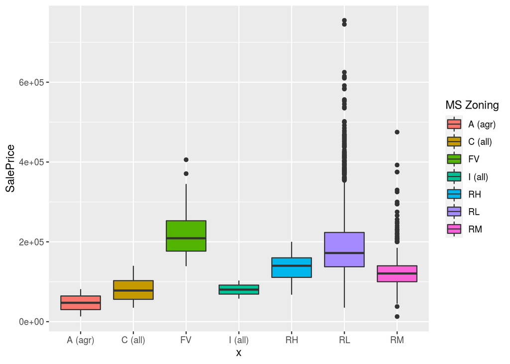

```r
ggplot(House, aes(x = 'MS Zoning', y = SalePrice, fill=`MS Zoning`))+geom_boxplot(aes(x = `MS Zoning`))
```

Level 별로 평균의 차이가 보이기에 MS Zoning을 설명변수 후보로 두겠다.

```r
House %>% group_by(`Lot Shape`) %>% summarize(mean = mean(SalePrice))
```

```
## # A tibble: 4 x 2
##   `Lot Shape`    mean
##   <chr>         <dbl>
## 1 IR1         210925.
## 2 IR2         229588.
## 3 IR3         221923.
## 4 Reg         162580.
```

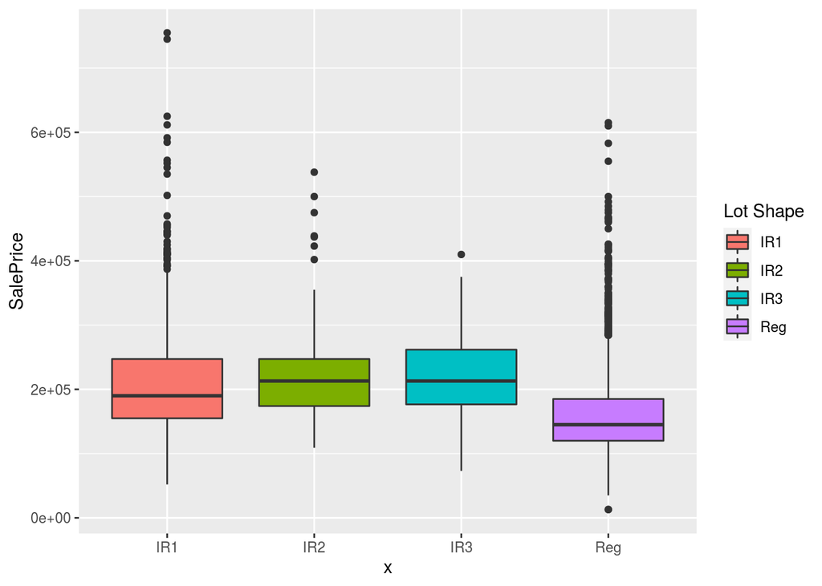

```r
ggplot(House, aes(x = 'Lot Shape', y = SalePrice, fill=`Lot Shape`))+geom_boxplot(aes(x = `Lot Shape`))
```

Level 별로 평균의 차이가 보이기에 Lot Shape의 level 중에서 IR와 Reg로 구별하여 설명변수 후보로 선정하겠다

```r
House %>% group_by(`House Style`) %>% summarize(mean = mean(SalePrice))
```

```
## # A tibble: 8 x 2
##   `House Style`    mean
##   <chr>           <dbl>
## 1 1.5Fin        137530.
## 2 1.5Unf        109663.
## 3 1Story        178700.
## 4 2.5Fin        220000
## 5 2.5Unf        177158.
## 6 2Story        206990.
## 7 SFoyer        143473.
## 8 SLvl          165527.
```

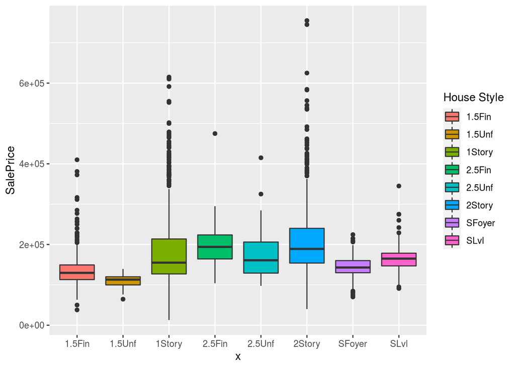

```r
ggplot(House, aes(x = 'House Style', y = SalePrice, fill=`House Style`))+geom_boxplot(aes(x = `House Style`))
```

Level 별로 평균의 차이가 보이기에 House Style를 설명변수 후보로 두겠다.

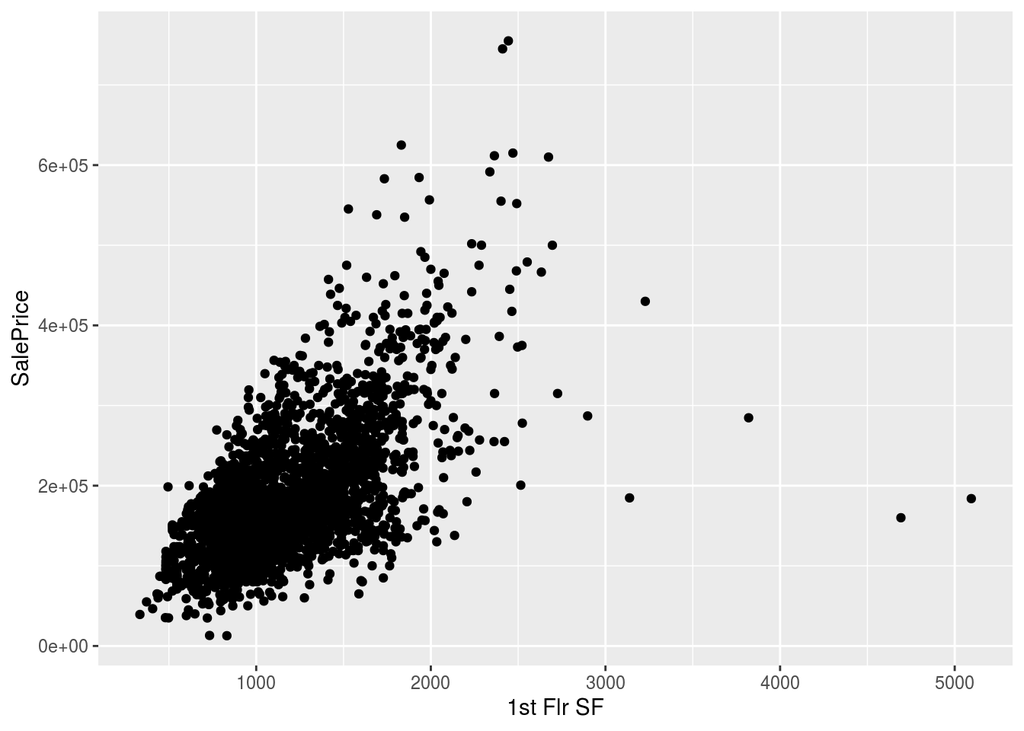

```r
ggplot(House, aes(x = `1st Flr SF`, y = SalePrice)) + geom_point()
```

1st Flr SF와 Sales Price간에 상관관계가 있는 것으로 보이므로 1st Flir SF를 설명변수 후보로 두겠다.

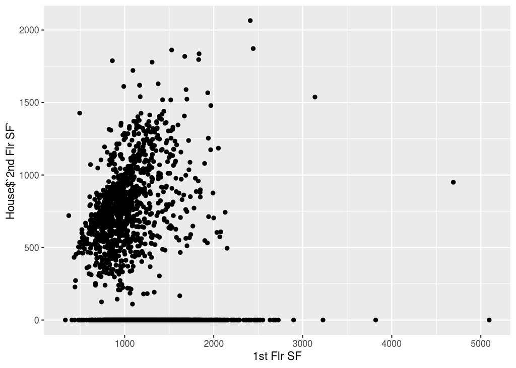

```r
ggplot(House, aes(x = `1st Flr SF`, y = House$`2nd Flr SF`)) + geom_point()
```

1st Flr 와 2nd Flr간에 상관관계가 있기에 2nd Flr는 설명변수로 제외하겠다.

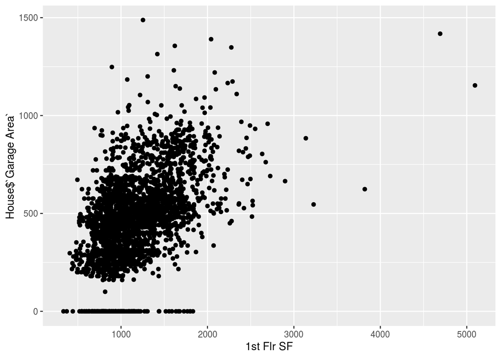

```r
ggplot(House, aes(x = `1st Flr SF`, y = House$`Garage Area`)) + geom_point()
```

Garage area와 1st Flr 간에 상관관계가 보이므로 Garage area도 제외하겠다. 즉, factor 후보로 MS Zoning, Lot Shape, House Style, 그리고 covariate 후보로 1st Flr 로 두겠다.